# MIS_Pronos_class_21_Feb2023: Métodos de descomposición

Sergibar

2023-02-21

# Materia: Pronosticos

# Dr. Jair Morales C.

## Alumno: Ibarra Raramírez Sergio (414025796)

## Fecha: Feb.2023, Clase 21.Feb.2023 Métodos de descomposición de series

## ‘Tecnica genralizada de suavizamiento de series de tiempo’

Comenzaremos instalando las liberias necesarias para el desarrollo

```r
library(tidyverse)      # data manipulation and visualization
library(lubridate)      # easily work with dates and times
library(fpp2)           # working with time series data
library(zoo)
```

```r
library(ggplot2)
library(plyr)
library(dplyr)
library(knitr)
library(TTR)
library(hydroGOF)
```

Instalaremos el package HydroGOF que nos permitirá calcular todo tipo de errores dados un valor “observado” y uno “calculado”

```r
install.packages("hydroGOF", repos = "http://cran.r-project.org/")
```

#### Desarrollo de ta técnica

Recordar que en las series de tiempo se poríaan identificar 3 componentes típicos: T-Tendencia E-Estacionalidad A-Componente aleatorio o ruido blanco

$$L = g(T,E,A)$$
Cuando tendencia y estacionalidad no están asociadas (MODELO ADITIVO)
$$y_{t1}= T_{t} + E_{t}+ A_{t}$$

Cuando tendencia y estacionalidad SI están asociadas (MODELO MULIPLICATIVO)

$$y_{t2}= T_{t} * E_{t}+
A_{t}$$

Dada una serie de tiempo a) Se suavizará mediante MA, WMA, EMA, etc b) Se puede estimar la tendencia “con un modleo lineal”

$$T_{t} = b0 + b1*t$$
(Se pueden tener también tendecias de tipo exponencial y/o polinomio por ejemplo)

Exponencial:

$$T_{t} =b0*e^{b1*t}$$

Polinomio:

$$T_{t} =b0 + b1*t + b1*t^2$$

3. Se establece una corrección con la SERIE SUAVIZADA

Mediante un modelo de tiepo por ejemplo (Aditivo o multiplicativo)

De esto se obtendrá una serie Resifual Wt que ya solamente incluirá el efecto estacional

Para el caso de MODELOS ADITIVOS

$$W_{t} = y_{t}-\ y_{t}
<media>$$

Entonces una vez suavizada, podemos calcular la tendencia (lineal, exponencial, polinomial). Una vez estimada la tendencia se tiene “una nueva serie de tiempo” una serue residual, de tal manera que a la serie original se le quita el uavizamiento y lo que se deja es la estacionalidad

Para el caso de MODELOS MULTIPLICATIVOS

$$W_{t} = y_{t}-/ y_{t}
<media>$$

4. Ahora se pasaría al analisis de los”componentes de estacionalidad”.

Sea Ei estimación de cada componente estacional (mensual, trimestral, semestral, etc)

Y sea S el total de observaciones para cada componente.

Y sea ei la observación para cada Ei

El componente (ya sea bimestral, trimestral, etc) va a ser el promedio de los (meses, trimeses, semestres, de esa serie de tiempo)

$$E_{i} =
\frac{1}{s}*\sum_{h=1}^{s}e_{h}$$

5. Por último la preddicción sería

-Para el caso aditivo:

$$Y<estimada>_{i} =
T<tendencia>_{t} + E<estacionalidad>_{i}$$

-Para el caso Multiplicativo:

$$Y<estimada>_{i} =
T<tendencia>_{t} * E<estacionalidad>_{i}$$

```r
# Create the data frame
serie_original <- data.frame(
  Trimestre = c("1er", "2do", "3er", "4to"),
  `2003` = c(120, 90, 90, 100),
  `2004` = c(130, 110, 110, 130),
  `2005` = c(140, 120, 110, 150),
  `2006` = c(150, 140, 140, 170),
  `2007` = c(180, 180, 170, 170)
)

# Print the data frame
serie_original
```

```
##   Trimestre X2003 X2004 X2005 X2006 X2007
## 1       1er   120   130   140   150   180
## 2       2do    90   110   120   140   180
## 3       3er    90   110   110   140   170
## 4       4to   100   130   150   170   170
```

```r
serie_original$X2003
```

```
## [1] 120  90  90 100
```

```r
typeof(serie_original$X2003)
```

```
## [1] "double"
```

### Continuación de la clase del 21.Feb.2023 para revisión de algunos métodos en R

```r
install.packages("TTR")
library(TTR)

### Precio de Acciones
accTV <- c(71,70,69,68,64,65,72,78,75,75,75,70,75,75,74,78,86,82,
        75,73,72,73,72,77,83,81,81,85,85,84)
length(accTV)
```

```
## [1] 30
```

```r
#### Medias Moviles
SMA(accTV, n=5)
```

```
##  [1]   NA   NA   NA   NA 68.4 67.2 67.6 69.4 70.8 73.0 75.0 74.6 74.0 74.0 73.8
## [16] 74.4 77.6 79.0 79.0 78.8 77.6 75.0 73.0 73.4 75.4 77.2 78.8 81.4 83.0 83.2
```

```r
sm1 <- stats::filter(accTV, rep(1/5,5), sides=2) ## retardo central
sm2 <- stats::filter(accTV, rep(1/5,5), sides=1)  ## sin retardo central
stats::filter(accTV, rep(1/3,3), sides=1)
```

```
## Time Series:
## Start = 1
## End = 30
## Frequency = 1
##  [1]       NA       NA 70.00000 69.00000 67.00000 65.66667 67.00000 71.66667
##  [9] 75.00000 76.00000 75.00000 73.33333 73.33333 73.33333 74.66667 75.66667
## [17] 79.33333 82.00000 81.00000 76.66667 73.33333 72.66667 72.33333 74.00000
## [25] 77.33333 80.33333 81.66667 82.33333 83.66667 84.66667
```

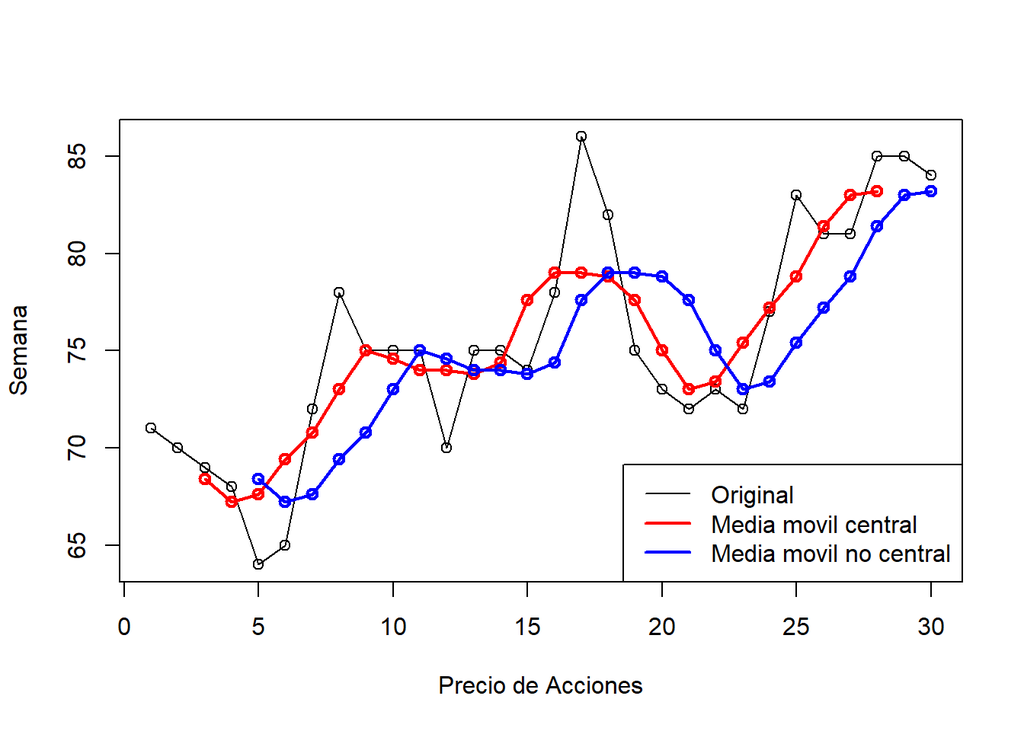

```r
#### Medias Moviles ponderadas
wt <- c(.15,.15,.3,.2,.2)
smw1 <- WMA(accTV, n=5, wts=1:5) ### lineal
smw2 <- WMA(accTV, n=5, wts=wt)

plot(accTV, main='', xlab='Precio de Acciones', ylab='Semana', type="o")
lines(sm1, col="red", lwd=2, type="o")
lines(sm2, col="blue", lwd=2, type="o")
legend("bottomright", c("Original", "Media movil central", "Media movil no central"), lwd=c(1,2,2), col=c("black", "red", "blue"))
```

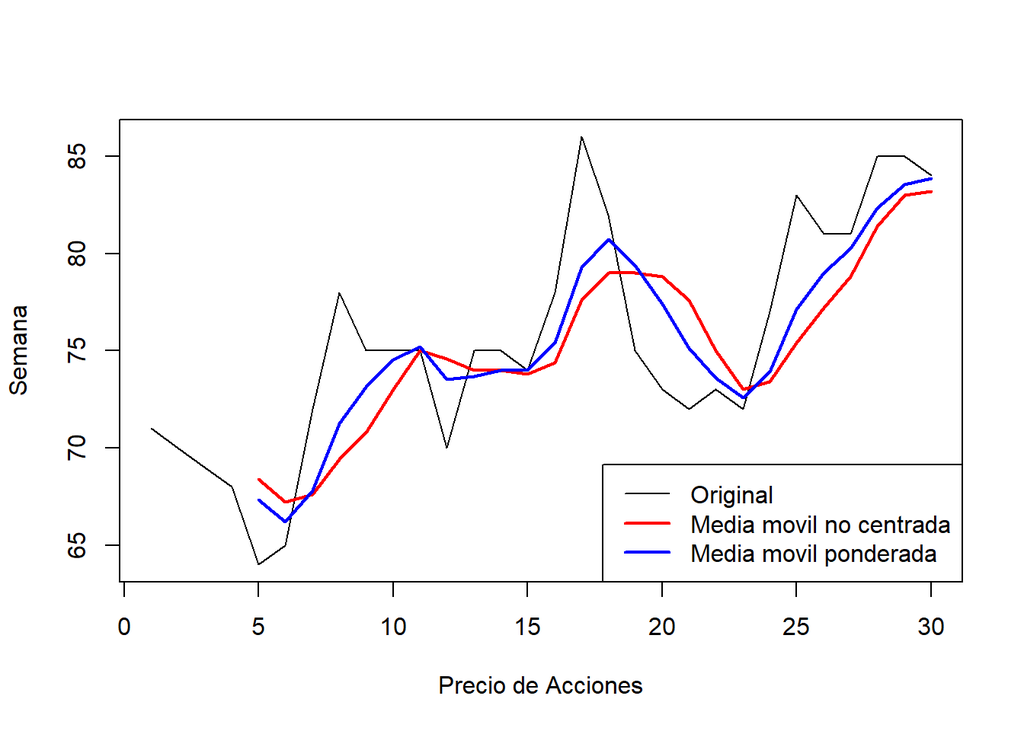

```r
plot(accTV, main='', xlab='Precio de Acciones', ylab='Semana', type="l")
lines(sm2, col="red", lwd=2)
lines(smw1, col="blue", lwd=2)
legend("bottomright", c("Original", "Media movil no centrada", "Media movil ponderada"), lwd=c(1,2,2), col=c("black", "red", "blue"))
```

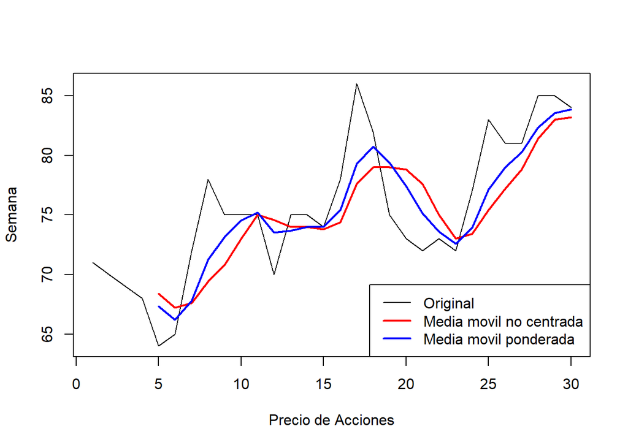

```r
plot(accTV, main='', xlab='Precio de Acciones', ylab='Semana', type="l")
lines(sm2, col="red", lwd=2)
lines(smw1, col="blue", lwd=2)
legend("bottomright", c("Original", "Media movil no centrada", "Media movil ponderada"), lwd=c(1,2,2), col=c("black", "red", "blue"))
```

```r
#### alisamiento exponencial
se1 <- EMA(accTV, n=1, ratio=.1)
se2 <- EMA(accTV, n=1, ratio=.5)
se3 <- EMA(accTV, n=1, ratio=.9)
```

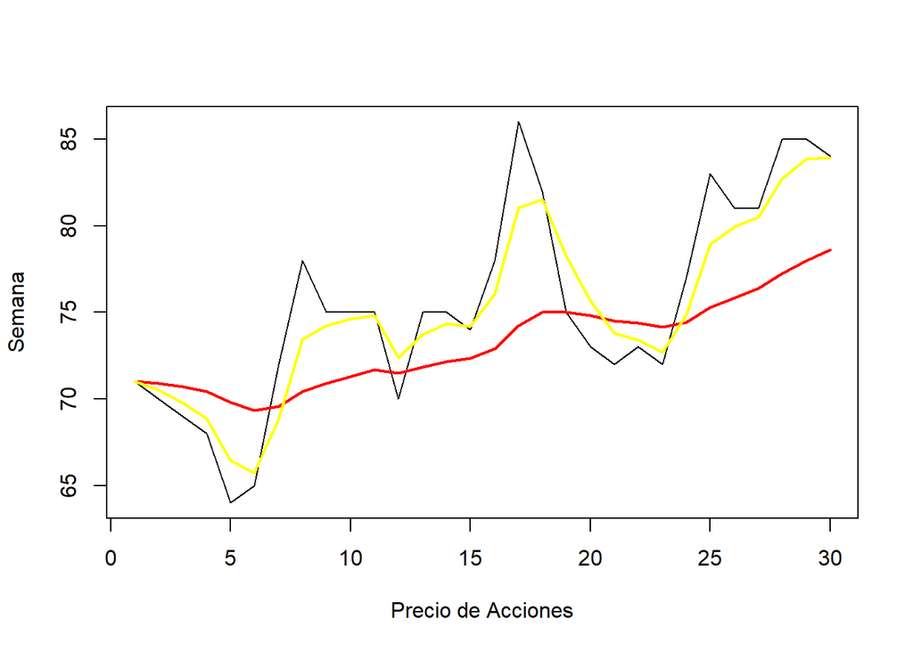

```r
plot(accTV, main='', xlab='Precio de Acciones', ylab='Semana', type="l")
lines(se1, col="red", lwd=2)
lines(se2,col="yellow", lwd=2)
```

Ahora haremos uso de la librería Forecast

```r
library(forecast)
```

Definamos una nueva serie

```r
sales_original <- c(197,211,203,247,239,269,308,262,258,256,261,288,296,276,305,308,356,393,363,386,443,308,358,384,358,325,414,406,425,347,413,435,407,438,479,373,437,500,535,525,449,557,543,433,475,592,548,520)
sales_original
```

```
##  [1] 197 211 203 247 239 269 308 262 258 256 261 288 296 276 305 308 356 393 363
## [20] 386 443 308 358 384 358 325 414 406 425 347 413 435 407 438 479 373 437 500
## [39] 535 525 449 557 543 433 475 592 548 520
```

Transformamos nuestra data a un tipo de dato “serie de tiempo”

```r
sales_ts <- ts(sales_original, frequency=12, start=(2005))
sales_ts
```

```
##      Jan Feb Mar Apr May Jun Jul Aug Sep Oct Nov Dec
## 2005 197 211 203 247 239 269 308 262 258 256 261 288
## 2006 296 276 305 308 356 393 363 386 443 308 358 384
## 2007 358 325 414 406 425 347 413 435 407 438 479 373
## 2008 437 500 535 525 449 557 543 433 475 592 548 520
```

Ploteamis la serie del tiempo

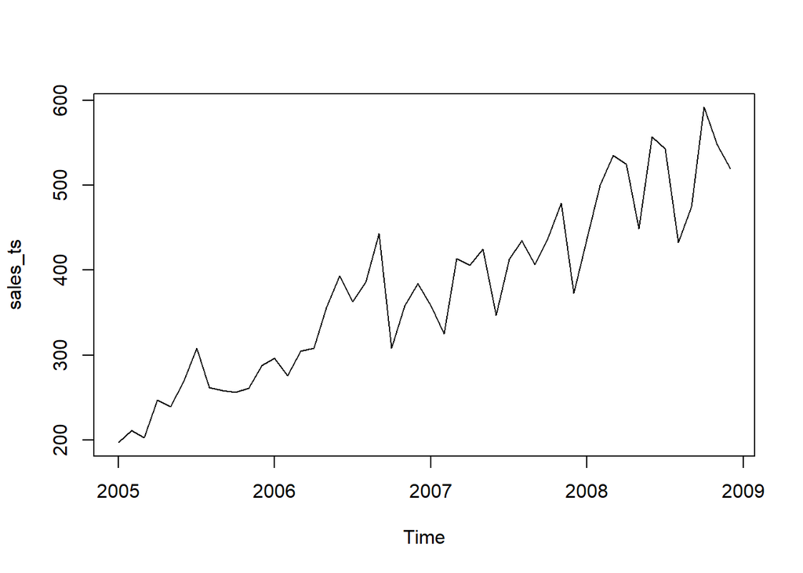

```r
plot(sales_ts)
```

Suavizamiento exponencial doble

```r
sales_exp<-ets(sales_original, alpha=0.1, additive.only=TRUE)
sales_exp
```

```
## ETS(A,A,N)
##
## Call:
##  ets(y = sales_original, alpha = 0.1, additive.only = TRUE)
##
##   Smoothing parameters:
##     alpha = 0.1
##     beta  = 1e-04
##
##   Initial states:
##     l = 207.8023
##     b = 6.9579
##
##   sigma:  41.3147
##
##      AIC     AICc      BIC
## 546.8780 547.8082 554.3628
```